# International Migration

Bruno de Melo

5/3/2020

# International Migration

Project goal is to analyse international migration based on data obtained on the UN and World Bank data sites.

Our objectives are:

1. Display graphically migration flows, migration trends over time, largest migration destination and origins.

2.Find evidence that more developed, wealthier regions or countries attract more migrants. We could also verify whether the converse is also true, meaning that regions or countries which are less developed have more people leaving their borders.

3.In terms of trend, we would like to check that countries becoming weathier over time, also tend to attract more people over time.

**1. Data set-up**

**2. Destination and Origin data set**

This is the main data set, it contains migration stock from several years for all countries in the world. It also contains info on some country classification.

**3. UN Development groups and World Bank’s Income group classifications of each country**

This is an auxiliary data set that contains country classification by UN Development and World Bank’s Income groups.

Cross reference is type factor but we need to convert to Logical

**4. UN and World Bank Classifications** There are several classifications listed in the data set. They are defined in the first 20 or so rows. These are the classification / groups:

1: UN development group: More developed, Less developed, least developed and Less developed ex-least 2: World Bank Income groups: High-, Middle-, Upper-Middle-, Lower-Middle-, Low-, No Income 3: Geographic Regions: Africa, Asia, Europe, Latin America & the Caribbean, Northern America, and Oceania. 4: Sustainable Development Goal (SDG) 7 regions:Sub-Saharan Africa, Northern Africa and Western Asia, Central and Southern Asia, Eastern and South-Eastern Asia, Latin America and the Caribbean, Oceania, and Europe and Northern America. These regions are further divided into 22 geographic subregions.

Cross reference is done by classification #1, #2 and 3 above. This will be enhanced with adding these specific codes to countries. We also need to classify all countries by #4, as this will help with data set containing migration data.

**5. Re-arranging classification and population data and joining datasets**

On both datasets, first lines will be deleted given that classification info was retrieved in separate data frames.

#**6. Exploratory Data Analysis on migration trend on regions and countries of destination and origin**

Data set contains historical data on migration for the years 1990, 1995,2000, 2005,2010, 2015 and 2019.

Here are some hipotheses I would like to test:

1:Find evidence that more developed, wealthier regions or countries attract more migrants. We could also verify whether the converse is also true, meaning that regions or countries which are less developed have more people leaving their borders.

2:In terms of trend, we would like to check that countries becoming weathier over time, also tend to attract more people over time.

**6.1. First, let’s check the total migration destination per country in 2019**

**6.2 This is an interactive map, showing the main migration routes in 2019 between countries with more than 1mn migrants leaving their borders.**

Plot

```r
# map projection
flows <- gcIntermediate(df_long1[,18:19], df_long1[,20:21], sp = TRUE, addStartEnd = TRUE)

flows$counts <- df_long1$TotalOrigin/1000000

flows$origins <- df_long1$Origin

flows$destinations <- df_long1$Destination

hover <- paste0(flows$origins, " to ",
                flows$destinations, ': ',
                as.character(round(flows$counts, digits=2)), " mn")

pal <- colorFactor(brewer.pal(4, 'Set2'), flows$origins)

leaflet() %>%
  addProviderTiles('CartoDB.Positron') %>%
  addPolylines(data = flows, weight = ~counts, label = hover,
               group = ~origins, color = ~pal(origins)) %>%
  addLayersControl(overlayGroups = unique(flows$origins),
                   options = layersControlOptions(collapsed = FALSE))
```

[interactive chart not shown]

There are some well know routes, like:  
Mexico-China-India to USA  
Algeria-Morocco to France  
UK to Australia  
Turkey to Germany

Others generated by geopotical issues, like war: Syria to Turkey  
Ukraine to Russia

**6.3 Using income-based classification, below shows the flow of migrants between regions in 2019, as classified by the World Bank.**

```r
# preparing dataset
data_long <- df_region[,c(1,5,2,6)] %>%
  filter(Year==2019)
data_long<- data_long[,-c(1)]
data_long$RegionOrigin<-str_replace_all(data_long$RegionOrigin,"countries","")
data_long$RegionDest<-str_replace_all(data_long$RegionDest,"countries","")
data_long$RegionOrigin<-str_replace_all(data_long$RegionOrigin,"group","")
data_long$RegionDest<-str_replace_all(data_long$RegionDest,"group","")
data_long$RegionOrigin<-str_replace_all(data_long$RegionOrigin,"available","")
data_long$RegionDest<-str_replace_all(data_long$RegionDest,"availble","")
```

Plot diagram

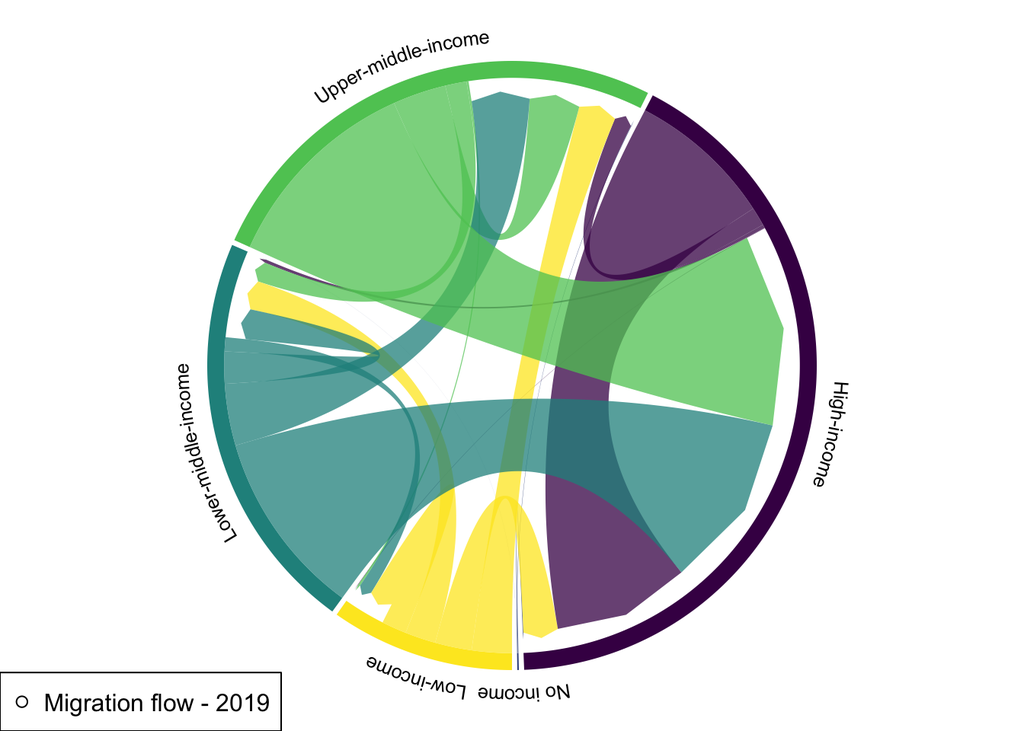

```r
# parameters
circos.clear()
circos.par(start.degree = -90, gap.degree = 1, track.margin = c(-0.1, 0.1), points.overflow.warning = FALSE)
par(mar = rep(0, 4))

# color palette
mycolor <- viridis(5, alpha = 1, begin = 0, end = 1, option = "D")
mycolor <- as.vector(mycolor[sample(1:5)])
#mycolor <- c("#FDE725FF","#21908CFF","#3B528BFF","#5DC863FF","#440154FF")

# Base plot
chordDiagram(
  x = data_long,
  grid.col = mycolor,
  transparency = 0.25,
  directional = 1,
  direction.type = c("arrows", "diffHeight"),
  diffHeight  = -0.04,
  annotationTrack = "grid",
  annotationTrackHeight = c(0.05, 0.1),
  link.arr.type = "big.arrow",
  link.sort = TRUE,
  link.largest.ontop = TRUE)
# Add text and axis

legend("bottomleft", pch = 1, legend = "Migration flow - 2019")
circos.trackPlotRegion(
  track.index = 1,
  bg.border = NA,
  panel.fun = function(x, y) {

    xlim = get.cell.meta.data("xlim")
    sector.index = get.cell.meta.data("sector.index")

    # Add names to the sector.
    circos.text(
      x = mean(xlim),
      y = 2.5,
      labels = sector.index,
      facing = "bending",
      cex = 0.8
      )
  }
)
```

As can be see, High-Income countries received the highest numbers of migrants, including from within its sector migration. Upper-middle-income group seems to have more migration than low-income group.

**6.4 Aggregated migration numbers**

**6.5 Exploring trends by different classifications.**

Let’s show graphically the international migrants as a percentage of total population over time in order to check trends.

Let’s check the number of migrants relative to the region total population.

2:World Bank Income classification The World Bank classifies the world’s economies into four income groups — high, upper-middle, lower-middle, and low. They base this assignment on Gross National Income (GNI) per capita (current US$) calculated using the Atlas method.

**6.6 Migration by country**

Let’s analyse the proportion that each country hosts migrants in relation to the total migration number.

**6.7 Let’s visualize in more detail the biggest migration flows between the US and its top migrantion source. (greater than 1mn of migrants).**

**6.8 Let’s analyse the flow to Turkey.**

#7 Relationship between Migration and Wealth

**7.1 Let’s analyse the relationship between migration and three economic variables:** Gross National Income (GNI) per capita: as a measure of wealth - (converted to U.S. dollars using the World Bank Atlas method, divided by the midyear population)  
GINI index: as a measure of inequality  
Personal Remittances (received as % of GDP): as a measure of family ties

**7.2 Visual inspection of GNI vs Total Migration by year and by income group.**

**7.3 Let’s plot GINI index vs total exits.**

A higher Gini index indicates greater inequality, with high income individuals receiving much larger percentages of the total income of the population.

**7.4 Let’s check if there’s any evidence between the amount of remmitances received and total exits, as an indication of family ties, in Lower- and Low-income countries.**

#8 Panel data regression analysis

Let’s build a panel data mode consisting of data for six years (1990, 1995, 2000, 2005, 2010,2015) for the three variables analysed above: GNI, Gini index and remittances received.

We will be using package plm (reference https://cran.r-project.org/web/packages/plm/vignettes/plmPackage.html)

**8.1 First model - total migration received:**

TotalMigration ~ GNI +Gini + PersonalRemittances

**8.2 Second model - total migration exited:**

**8.3 Let’s filter for some countries and include only countries within the Low-Income groups.**

**8.4 Let’s focus on Total migration received for some countries within the High- and Low-Middle-Income groups.**

**8.5 Instead of regression three variables, let’s regress only one.**

Gini index vs Exits

Let’s try Remittances received vs Total Migration.

Let’s run again Total Migration received vs GNI.

### Conclusion

Project consisted of showing migration flows between countries and of trying to model and estimate which variables could dtermine such behaviour.

It is very clear from the data, at least visually, that wealth and family ties play an important part in the migration flow.

Not neglegible is also geopolitical considerations, like wars.